# Sintetinės biologijos projektas

Acinetobacter baumannii bakterijų, paveiktų toksinu CheT, proteominių duomenų analizė

Beatričė Radavičiūtė

December 20, 2018

# Įvadas

Mano nagrinėjami duomenys gauti toksinu CheT veiktų bakterijų *Acinetobacter baumannii* bei kontrolinių bakterijų (nepaveiktų toksinu) lizatus tyrus masių spektrometrijos metodu. Visi tyrimai atlikti Gyvybės mokslų centre. Darbe pateikiami jau apdotori duomenys, kuriuose nurodoma nustatytų bakterijose peptidų pavidinimai, jų raiškos pokytis, lyginant su kontrolinėmis bakterijomis bei kitos charakteristikos. Šio darbo tikslas yra atlikti kintamųjų aprošomosios statiskos analizę. Taip pat darbo metu bus bandoma nustatyti, ar tarp kintamųjų (nustatytų baltmų charakteristikų) yra koreliacija, priežastinis ryšys ir kt.

# Duomenų įsikėlimas, peržiūra, pradinė analizė

## Duomenų peržiūra

Įsikeliami duomenys, nustatomas charakteristikų (variables) ir nustatytų baltymų (observations) skaičius, kintamųjų tipas.

```
## Observations: 1,344
## Variables: 20
## $ description         <chr> "Acyl-CoA dehydrogenase OS=Acinetobacter b...
## $ IEP                 <dbl> 5.54, 5.30, 4.69, 4.84, 4.53, 9.87, 5.24, ...
## $ mw                  <dbl> 65872.10, 76792.25, 37183.58, 22315.70, 36...
## $ `max score`         <dbl> 3658.1450, 779.0961, 255.2396, 1830.3930, ...
## $ accession           <chr> "A0A1G5LU08", "A0A241YAV2", "A0A1C9CQK6", ...
## $ `reported peptides` <dbl> 3, 16, 3, 7, 13, 7, 11, 6, 25, 9, 7, 11, 6...
## $ `sequence coverage` <dbl> 7.49, 38.96, 13.86, 55.72, 45.59, 55.35, 5...
## $ `FDR level`         <dbl> 0, 0, 0, 0, 0, 0, 0, 0, 0, 0, 0, 0, 0, 0, ...
## $ entry               <chr> "A0A1G5LU08_ACIBA", "A0A241YAV2_ACIBA", "A...
## $ K1                  <dbl> 7336.7442, 4498.4030, 6098.0000, 4677.4877...
## $ K2                  <dbl> 8147.7455, 5594.2167, 6321.5000, 4949.2173...
## $ K3                  <dbl> 8346.3076, 12322.5575, 4043.0000, 4994.310...
## $ T1                  <dbl> 0.0000, 0.0000, 0.0000, 0.0000, 0.0000, 0....
## $ T2                  <dbl> 0.0000, 0.0000, 0.0000, 0.0000, 0.0000, 0....
## $ T3                  <dbl> 0.0000, 0.0000, 0.0000, 0.0000, 0.0000, 0....
## $ avg_K10             <dbl> 7943.5991, 7471.7258, 5487.5000, 4873.6717...
## $ avg_T10             <dbl> 0.0000, 0.0000, 0.0000, 0.0000, 0.0000, 0....
## $ logFC               <dbl> -12.953526, -12.724876, -12.394068, -12.25...
## $ P.Value             <dbl> 4.390731e-12, 3.946895e-08, 6.940879e-10, ...
## $ adj.P.Val           <dbl> 1.180228e-09, 1.360161e-06, 3.109514e-08, ...
```

```
## Observations: 1,344
## Variables: 18
## $ IEP                 <dbl> 4.90, 5.44, 4.87, 4.49, 7.44, 5.80, 5.59, ...
## $ mw                  <dbl> 10129.64, 41645.43, 26205.95, 19170.71, 20...
## $ `max score`         <dbl> 35042.1500, 6539.5190, 7178.4810, 444.8390...
## $ `reported peptides` <dbl> 5, 15, 13, 3, 9, 8, 15, 14, 16, 18, 23, 18...
## $ `sequence coverage` <dbl> 71.88, 46.92, 70.37, 27.91, 78.07, 41.21, ...
## $ `FDR level`         <dbl> 0, 0, 0, 0, 0, 0, 0, 0, 0, 0, 0, 0, 0, 0, ...
## $ K1                  <dbl> 135483.333, 4461.333, 37535.667, 4089.667,...
## $ K2                  <dbl> 149256.000, 4091.667, 43926.000, 3772.333,...
## $ K3                  <dbl> 167503.667, 10768.000, 45422.667, 4156.000...
## $ T1                  <dbl> 132090.333, 5321.667, 45934.000, 4588.333,...
## $ T2                  <dbl> 175413.333, 8561.333, 49163.000, 4381.000,...
## $ T3                  <dbl> 188138.667, 16920.333, 48734.000, 4185.667...
## $ avg_K10             <dbl> 150747.667, 6440.333, 42294.778, 4006.000,...
## $ avg_T10             <dbl> 165214.111, 10267.778, 47943.667, 4385.000...
## $ logFC               <dbl> 0.121326863, 0.657090910, 0.185100563, 0.1...
## $ P.Value             <dbl> 0.4799392164, 0.2711783419, 0.1123523767, ...
## $ adj.P.Val           <dbl> 0.73216607, 0.58152015, 0.37845011, 0.4587...
## $ id                  <int> 1, 2, 3, 4, 5, 6, 7, 8, 9, 10, 11, 12, 13,...
```

Žemiau pateiktoje lentelėje išvardintos kitų kintamųjų pavadinimai ir jų reikšmės.

Kintamųjų pavadinimai ir jų reikšmės.

| Pavadinimai | Reikšmės |
| --- | --- |
| IEP | Izoelektrinis taškas |
| mw | Molekulinis svoris |
| max score | Didžiausia suminė jonų krūvio vertė atitinkamam peptidui |
| reported peptides | Nustatytų peptidų skaičius |
| sequence coverage | Sekos perdengimas |
| K1 | 1 kontrolinis mėginys |
| K2 | 2 kontrolinis mėginys |
| K3 | 3 kontrolinis mėginys |
| T1 | 1 tiriamasis mėginys |
| T2 | 2 tiriamasis mėginys |
| T3 | 3 tiriamasis mėginys |
| avg_K10 | Kontrolinių mėginių vidurkis |
| avg_T10 | Tiriamųjų mėginių vidurkis |
| logFC | Pokyčio logaritmas, kurio pagrindas 2 |
| P.Value | Pvertė, nusako statistinį duomenų patikimumą |
| adj.P.Val | Koreguota P vertė |

## Pradinė duomenų analizė

Pašalinus kategorinius kintamuosius, galima atlikti dar keletą veiksmų, kad su duomenimis būtų galima dirbti paprasčiau. Visų pirma, **FDR level** charakteristika nusako masių spektrometrijos metu nustatytų peptidų patikimumą. Kai FDR level = 0, peptidai nustatyti teisingai. Šiame darbe nagrinėjami visi peptidai, kurių FDR level = 0, taigi šią charakteristiką galima pašalinti, kadangi tai konstanta.

**log FC** charakteristika nusako nustatyrų peptidų raiškos pokytį tarp toksinu veiktų bakterijų ir kontrolinių bakterijų mėginių bei gali būti išreikšta formule **$2^n$**, kur n = log FC vertė. Todėl pravartu šią vertę apsiskaičiuoti ir pridėti naują stulpelį į duomenų lentelę, pavadinimu “expression”.

# Aprašomoji statistika

Apačioje pateiktuose paveiksluose pateikti kintamųjų grafikai, kuriuose atsispindi jų pasiskirstymas, pasiskirstymo simetrija, didžiausios ir mažiausios reikšmės, mediana, 1 ir 3 kvartiliai.

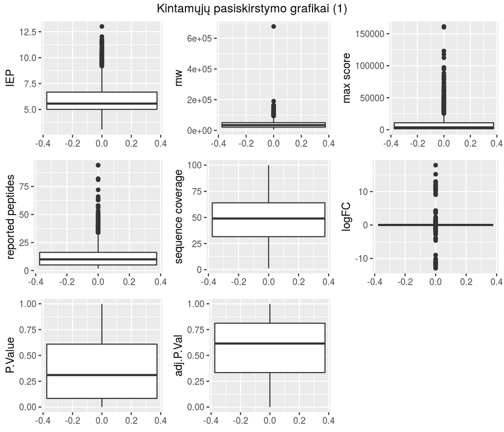

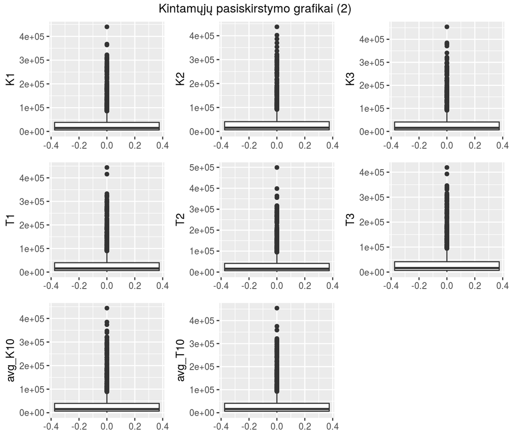

Toliau pateiktoje suvestinėje yra dauguma statistinių kiekvieno kintamojo įverčių.

```
## data_1
##
##  18  Variables      1344  Observations
## ---------------------------------------------------------------------------
## IEP
##        n  missing distinct     Info     Mean      Gmd      .05      .10
##     1344        0      476        1    6.269     1.89    4.521    4.680
##      .25      .50      .75      .90      .95
##    5.010    5.570    6.680    9.567   10.008
##
## lowest :  3.06  3.55  3.60  3.65  3.70, highest: 11.71 11.73 11.75 12.03 13.01
## ---------------------------------------------------------------------------
## mw
##        n  missing distinct     Info     Mean      Gmd      .05      .10
##     1344        0     1344        1    40698    28655    11216    13961
##      .25      .50      .75      .90      .95
##    20938    34053    49988    77244    96916
##
## lowest :   4923.749   4938.595   5175.187   5677.590   6071.789
## highest: 162706.079 163962.616 164006.641 190225.138 676512.999
## ---------------------------------------------------------------------------
## max score
##        n  missing distinct     Info     Mean      Gmd      .05      .10
##     1344        0     1342        1     9978    13203    437.2    612.3
##      .25      .50      .75      .90      .95
##   1278.8   3618.5  10833.2  29585.2  40716.3
##
## lowest :    123.1164    126.1948    153.1083    177.5567    185.3649
## highest: 112399.7000 117884.4000 123060.9000 160039.5000 161357.7000
## ---------------------------------------------------------------------------
## reported peptides
##        n  missing distinct     Info     Mean      Gmd      .05      .10
##     1344        0       61    0.998    12.83    10.97     2.00     3.00
##      .25      .50      .75      .90      .95
##     5.00    10.00    16.25    27.00    35.00
##
## lowest :  2  3  4  5  6, highest: 66 72 81 82 94
## ---------------------------------------------------------------------------
## sequence coverage
##        n  missing distinct     Info     Mean      Gmd      .05      .10
```

[output cut: 108 more lines]

```
##      .25      .50      .75      .90      .95
##   336.75   672.50  1008.25  1209.70  1276.85
##
## lowest :    1    2    3    4    5, highest: 1340 1341 1342 1343 1344
## ---------------------------------------------------------------------------
## expression
##        n  missing distinct     Info     Mean      Gmd      .05      .10
##     1344        0     1344        1    249.3    495.9   0.6293   0.7715
##      .25      .50      .75      .90      .95
##   0.9157   1.0181   1.1284   1.3044   1.5757
##
## Value           0   2000   4000   6000   8000  38000 244000
## Frequency    1327      9      3      1      2      1      1
## Proportion  0.987  0.007  0.002  0.001  0.001  0.001  0.001
## ---------------------------------------------------------------------------
```

Ryškiausiai matosi tai, kad biologinėse mėginių replikose (K1, K2, K3 ir T1, T2, T3) nėra itin didelių skirtumų, todėl toliau bus naudojami jų vidurkiai (avg_K10 ir avg_T10).

# Duomenų gavyba (data mining)

Pagrindinis šio etapo tikslas - nustatyti, ar tarp kintamųjų yra sąsajų, kurias būtų galima aptikti statistiniais metodais. Šiam tikslui pasiekti bus pasitelkiama koreliacijos analizė.

## Koreliacijos nustatymas

Sudaroma koreliacijos lentelė

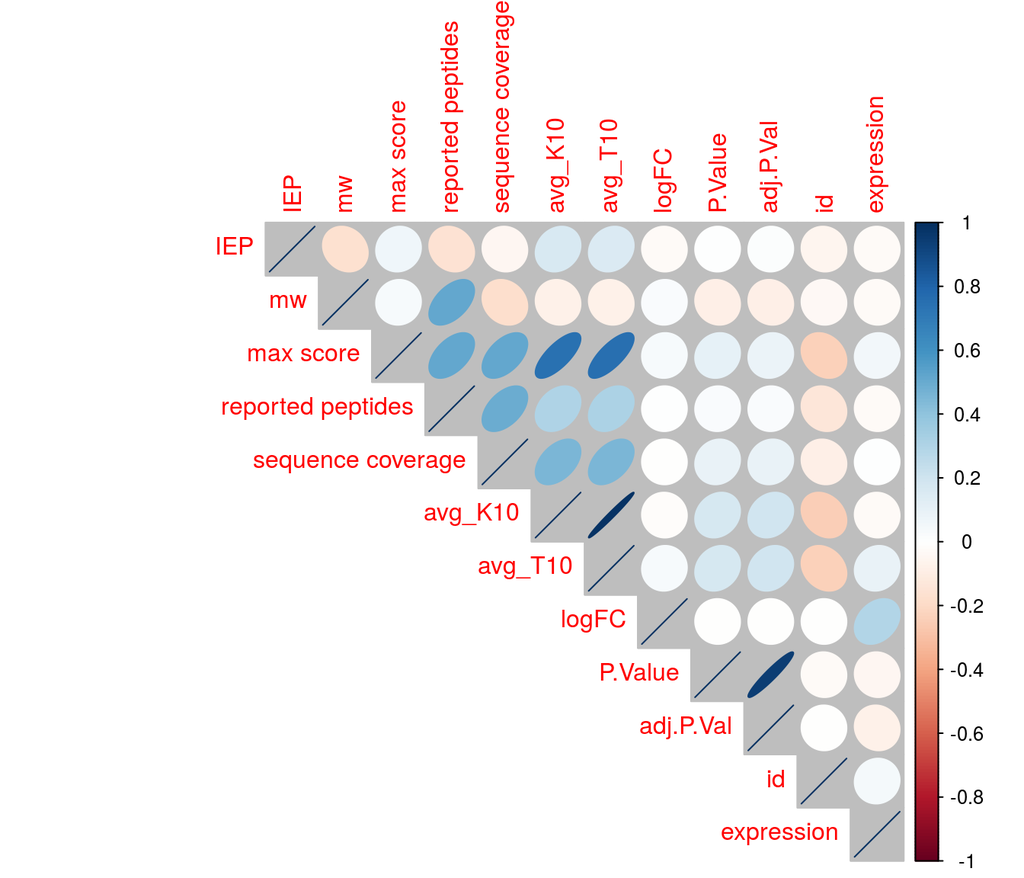

Elipsių spalvos intensyvumas bei forma nurodo koreliacijos stiprumą.

Patikrinamos koreliacijos p reikšmės.

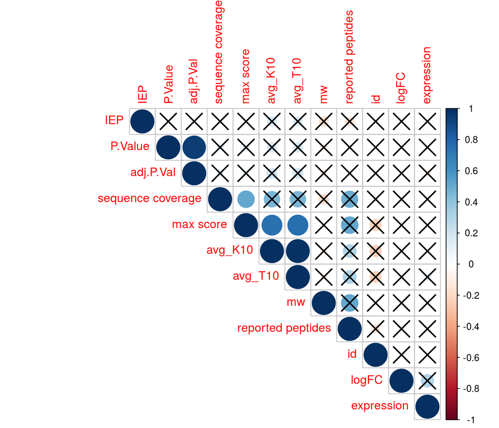

Užbraukti langeliai rodo, jog koreliacija nėra statistiškai patikima (p reikšmė > 0.01).

Tikrinamas sąryšis tarp K10 ir T10 vidurkių. Dar kartą nustatoma, ar duomenų pasiskirstymas yra normalusis.

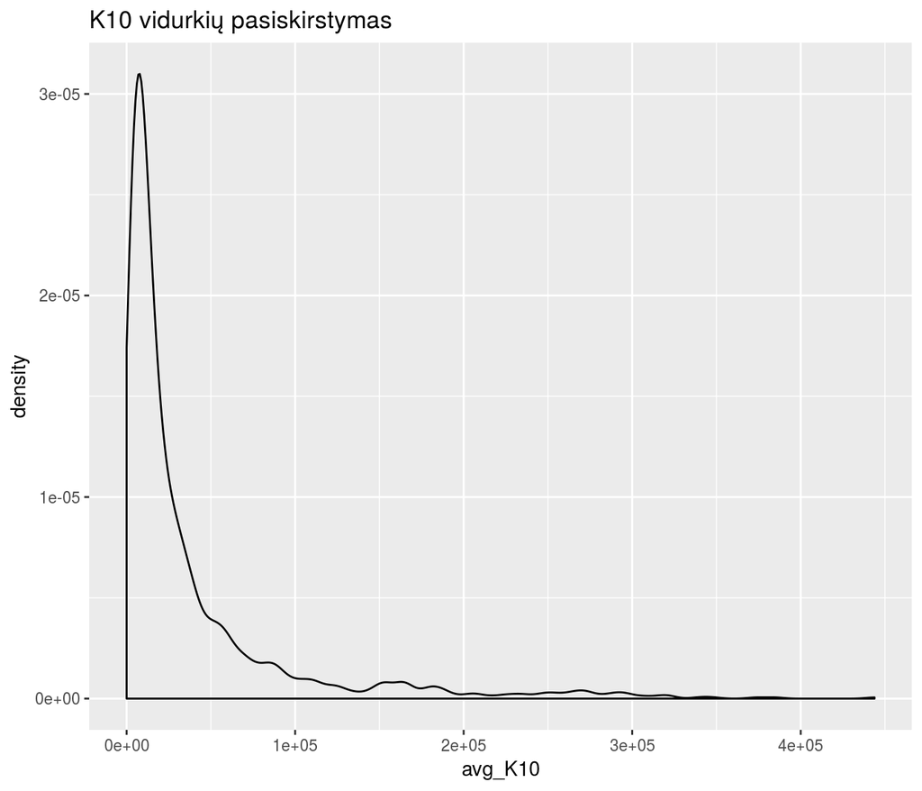

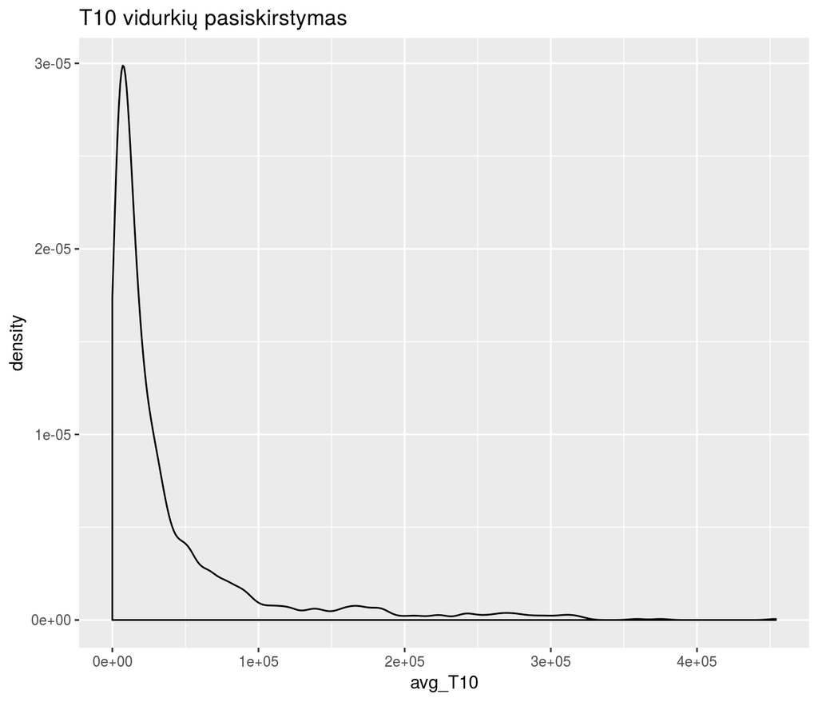

Kadangi skirstiniai n4ra normalieji, T testas negali būti taikomas šiems duomenims.

```
##
##  Wilcoxon signed rank test with continuity correction
##
## data:  data_1$avg_K10 and data_1$avg_T10
## V = 396860, p-value = 0.0001094
## alternative hypothesis: true location shift is not equal to 0
```

Iš gautų statistikų matome, kad populiacijos yra neidentiškos, o duomenys yra statistiškai patikimi (p < 0.001).

Toliau grafiškai atvaizduojama kintamųjų poros, bandoma nustatyti, ar yra tiesinė koreliacija tarp jų.

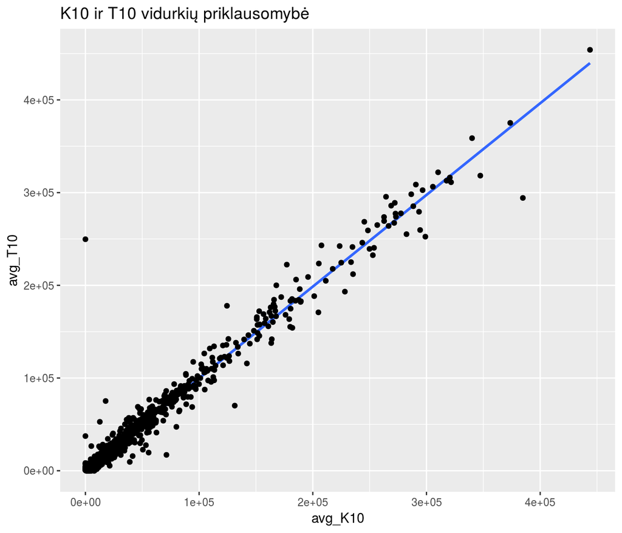

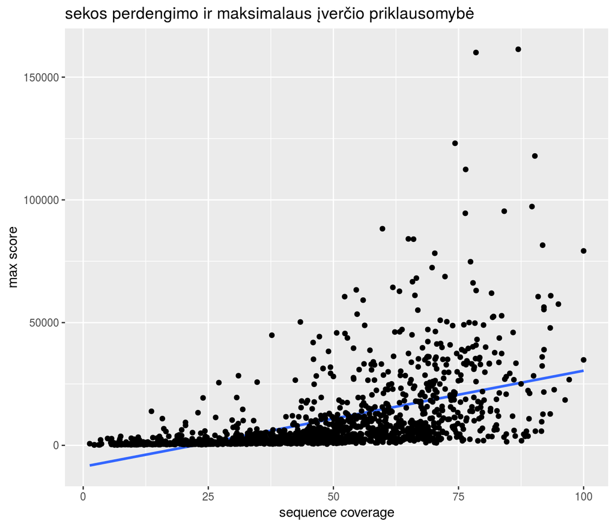

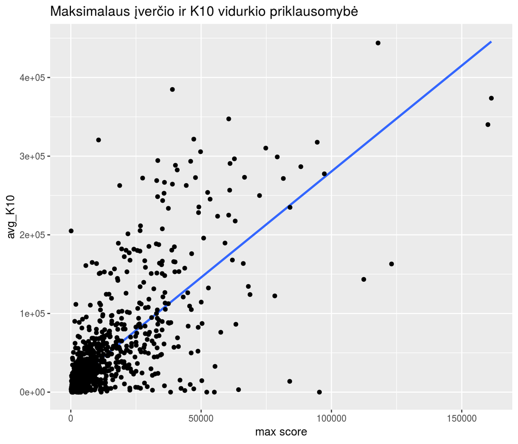

[figure not shown]

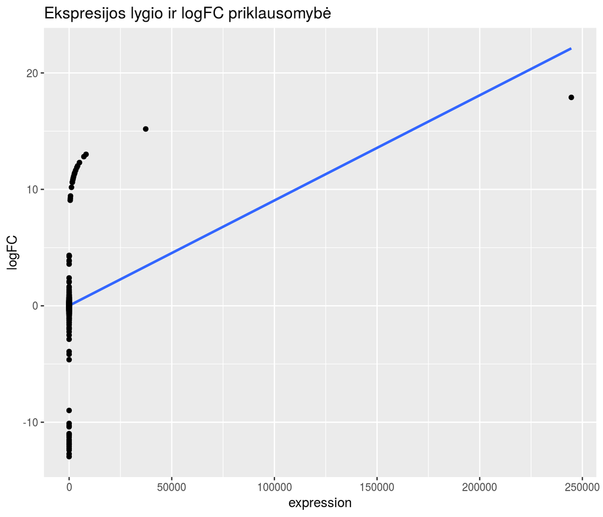

## Principinių komponenčių analizė

Kadangi tarp kai kurių kintamųjų galima koreliacija, sąsajoms įžvelgti galima naudoti ir principinių komponenčių analizę. Ši analizė itin pravarti, kai duomenų lentelėje yra daug kintamųjų (dimensijų), o taip ir yra šiuo atveju.

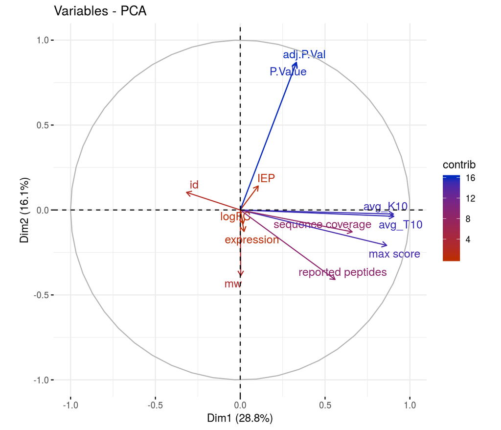

# Aptarimas